# Final

Andrew Edelblum

2/19/2019

OK, time to get this gravy train a-rollin’!

For my EDLD 610 final portfolio, I will be working with primary data from my current research on the impact of brand activism on subsequent consumer action.

# The Project

The project investigates the degree to which statements released from brands in support of divisive socio-political issues elicit pro-issue consumer response. Our guiding theoretical framework posits that self-brand connection (SBC), or the degree of identity-based overlap between self and brand, is a key determinant that shapes the hypothesized positive relationship between brand activism and subsequent consumer response. More specifically, high- (vs. low-) SBC consumers should view the brand’s activism as an exemplar for their own.

Drawing on balance theory, an established conceptualization of attitude formation and modeling, we suggest that individuals seek self-coherence by achieving attitudinal balance with those to whom they feel connected. Notably, if the consumer feels connected to the brand, and the brand asserts a connection to a given activist cause, then the consumer should follow by aligning themselves with that same cause, i.e., to maintain self-coherence.

# The Data

The visualizations you are about to see come from one particular study in this line of research. In this study, we examined donation behavior in connection to an external source of activism. This was meant to ensure that demand characteristics of the study design did not explain the focal effect. An opportunity for such a design presented itself on September 4, 2018, when the athletic apparel brand Nike selected as their spokesperson football player Colin Kaepernick, who is famous for his civil rights demonstrations at NFL games (Draper and Belson 2018).

Nike’s choice of Kaepernick was activist in nature; it signaled Nike’s support for civil rights and those who advocate for them. We reasoned that only some consumers would be aware of this breaking news and therefore tested whether knowledge of Nike’s activism increased high (vs. low) SBC consumers’ donations to a civil rights group (Black Lives Matter). We recorded donations first, such that no other study-related details could influence the focal effects. There is no identifiable information in my data sources.

**Note:** I ran this study on the same day as Nike first unveiled their 30th anniversary campaign. This was done to capitalize on a natural and ecologically valid instance of brand activism in popular culture, as well as draw comparisons between those who were and were not aware of it. If I waited too long, there would not be a baseline “no awareness” group from which to draw comparisons.

# Data Import

We’ll begin by importing the data. There are a few continuous variables we’ll have to calculate. First, because SBC is derived from a seven-item scale, we’ll add each subject’s values for these items and average them. We’ll do the same for their self-reported attitude toward the focal cause (i.e., Black Lives Matter).

# Main Effect of SBC on Donations

Time to finally put our data visualization skills to the test. First, I would like to see that the hypothesized main effect of self-brand connection (SBC) on donations came through. This should demonstrate that that the more connected an individual consumer feels to an activist brand, the more they will want to donate to a related activist cause (i.e., Black Lives Matter).

We will do this by plotting the regression line via `geom_smooth`, with the standard error included. (Visualizing uncertainty is integral to how we draw inferences from data, after all.) On top of the regression line, we will also plot the raw data. Since participants were given only a range of $0-10 to donate to Black Lives Matter, you will notice some binning in the data. For example, there is data clumping at certain dollar intervals.

```
##
## Call:
## lm(formula = donate_3 ~ sbcavg, data = d)
##
## Residuals:
##    Min     1Q Median     3Q    Max
## -4.341 -2.077 -1.407  1.630  8.592
##
## Coefficients:
##             Estimate Std. Error t value Pr(>|t|)
## (Intercept) 1.407484   0.286856   4.907 1.51e-06 ***
## sbcavg      0.032497   0.005806   5.597 4.85e-08 ***
## ---
## Signif. codes:  0 '***' 0.001 '**' 0.01 '*' 0.05 '.' 0.1 ' ' 1
##
## Residual standard error: 3.008 on 306 degrees of freedom
## Multiple R-squared:  0.09286,    Adjusted R-squared:  0.0899
## F-statistic: 31.33 on 1 and 306 DF,  p-value: 4.851e-08
```

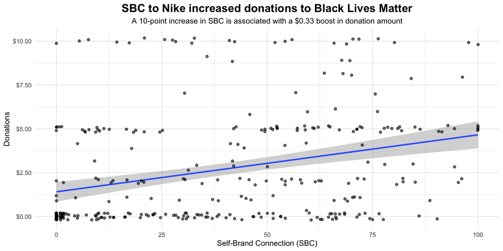

# SBC by Activism Awareness Interaction on Donations

Now for the real deal. My guiding theoretical framework suggests that consumers will align their activism with that of a connected *when* that brand demonstrates activism behavior. As such, it is integral to see how consumers decided to donate when they did versus did not know of Nike’s 30th anniversary campaign with Colin Kaepernick. Running this study on launch day of the campaign allowed for me to draw comparisons between these two groups before the campaign was covered on the evening news.

## Knowledge of Nike’s Activism

I wanted to see how many participants knew vs. did not know of Nike’s activism. In the study, I asked participants to write about any recent news they heard about Nike lately. I coded knowledge as “1” when participants either mentioned Colin Kaepernick by name or said something about the controversy surrounding Nike’s new spokesperson. Participants were coded as “0” otherwise.

Here is the table of results.

| Activism Awareness | n |
| --- | --- |
| No | 156 |
| Yes | 152 |

A roughly equal number of participants knew vs. did not know about Nike’s activism. Awesome!

Now, let’s see whether knowledge of activism interacts with SBC.

## Johnson-Neyman Plot

This next visualization took a bit of work to figure out. I’d like to see if awareness of Nike’s Kaepernick campaign interacted with SBC to affect donations to Black Lives Matter. Given my theorizing, high-SBC consumers should increase their donations most when they know of Nike’s activism. Consumers achieve self-coherence when they align their behavior with that of an self-relevant associative in-group. Can brand activism influence consumer activism?

I have a continuous predictor (SBC) and a categorical predictor (activism awareness). As such, I can use floodlight analysis to communicate at what specific threshold values of SBC there emerges a significant difference between being aware vs. unaware of Nike’s activism. I performed this floodlight analysis using the HAYES macro in SPSS. You can see the results in a screenshot below.

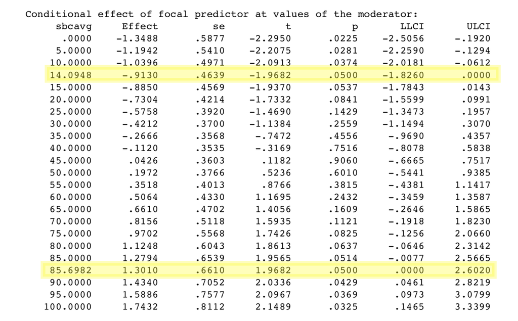

As can be seen from the output above, the threshold points are at 14.09 and 85.70. That means all simple effects at SBC < 14.09 are significant, and all simple effects at SBC > 85.70 are significant.

```
##
## Call:
## lm(formula = donate_3 ~ sbcavg * know2, data = d)
##
## Residuals:
##     Min      1Q  Median      3Q     Max
## -4.9307 -2.1808 -0.8745  1.7536  8.0145
##
## Coefficients:
##                Estimate Std. Error t value Pr(>|t|)
## (Intercept)     0.81258    0.39840   2.040   0.0423 *
## sbcavg          0.04561    0.00810   5.631 4.08e-08 ***
## know2No         1.22486    0.57056   2.147   0.0326 *
## sbcavg:know2No -0.02677    0.01155  -2.318   0.0211 *
## ---
## Signif. codes:  0 '***' 0.001 '**' 0.01 '*' 0.05 '.' 0.1 ' ' 1
##
## Residual standard error: 2.991 on 304 degrees of freedom
## Multiple R-squared:  0.1093, Adjusted R-squared:  0.1005
## F-statistic: 12.43 on 3 and 304 DF,  p-value: 1.084e-07
```

[figure not shown]

SBC positively affects donation intentions for those with and without knowledge of Nike’s activism. However, knowledge moderates the strength of SBC’s effect on donation intentions.

Donation intentions for Black Lives Matter were *highest* when participants had a strong connection to Nike and were aware of its activism. The caveat is that donation intentions for Black Lives Matter were *lowest* when participants had a weak connection to Nike and knew of its activism. This provides some evidence that consumers use their association with or disassociation from a focal brand to decide how to engage with a particular activist cause.

But now another question emerges: What happens when we throw political orientation into the mix?

# Political Orientation?

To begin, we’ll clean the data a bit. The following code chunk accomplishes three main tasks:

1. Remove all participants who indicated their political orientation as “Other.”
2. Turn SBC into a categorical variable by doing a median split. All values above the median score for SBC will be coded as “High,” while all values below the median score for SBC will be coded as “Low.” **Note:** Median splits *are* an outdated form of data manipulation. However, because the following visualizations are intended for more of a general audience, I thought it would be an appropriate means of communicating the data.
3. Create a summary dataframe with mean, standard deviation, and standard error information for self-identified conservatives, liberals, and moderates at the two values of SBC (i.e., high vs. low), as well as the two values of activism awareness (yes vs. no).

## Identifying the Distribution for Each Political Orientation

While perhaps not the most illustrative visualization of the data, the follow density plot depicts the overall distribution of donations to Black Lives Matter by three political orientations: conservative, liberal, and moderate.

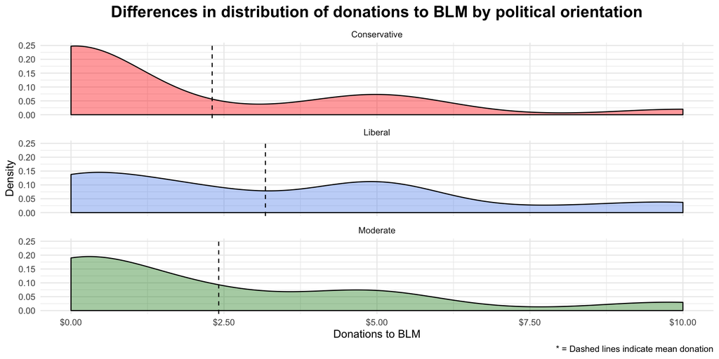

It is interesting to see that there is more of a right skew to the distribution for conservatives and moderates than for liberals. This makes sense, as the cause, Black Lives Matter, aligns more with left-leaning political motives than right-leaning. But there might be more than meets the eye going on with the data here. Let’s look at how SBC and activism awareness affected donations to BLM by political orientation.

To make comparisons as easy as possible, we will also drop moderates from the visualization and consider only the difference between conservatives and liberals.

## Did SBC and Awareness Influence Donations for Conservatives and Liberals?

Uh oh, it’s time to make the dreaded **dynamite plot**! I’d like to compare donations to Black Lives Matter by political orientation, SBC, and activism awareness, complete with error bars to visualize uncertainty.

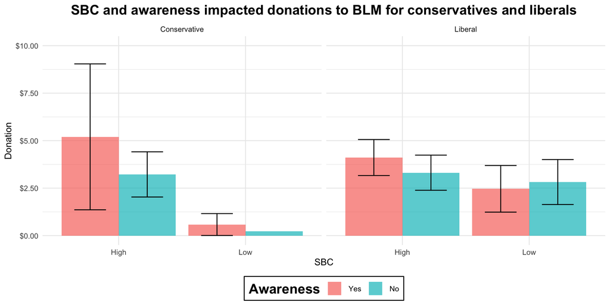

Interestingly, there was somewhat of a crossover interaction for liberals, such that being aware (vs. unaware) of Nike’s activism led to increased donations at high SBC, but decreased donations at low SBC.